# DSC 423: Data Analysis & Regression

## Assignment 7: Regression Pitfalls

```
Name: Kushal Navghare
Student ID: 2116916
Honor Statement: I, Kushal Navghare, assure that I have completed this work independently.
The solutions given are entirely my own work.
```

#### 1. Download the Pisa2009 Dataset from the D2L. The Programme for International Student Assessment (PISA) is a test given every three years to 15-year-old students from around the world to evaluate their performance in mathematics, reading, and science. This test provides a quantitative way to compare the performance of students from different parts of the world. In this homework assignment, we will predict the reading scores of students from the United States of America on the 2009 PISA exam. The dataset contains information about the demographics and schools for American students taking the exam, derived from 2009 PISA Public-Use Data Files distributed by the United States National Center for Education Statistics (NCES). Each row in the dataset represents one student taking the exam. The datasets have the following variables:

1. grade: The grade in school of the student (most 15-year-olds in America are in 10th grade)
2. male: Whether the student is male (1/0)
3. raceeth: The race/ethnicity composite of the student
4. preschool: Whether the student attended preschool (1/0)
5. expectBachelors: Whether the student expects to obtain a bachelor’s degree (1/0)
6. motherHS: Whether the student’s mother completed high school (1/0)
7. motherBachelors: Whether the student’s mother obtained a bachelor’s degree (1/0)
8. motherWork: Whether the student’s mother has part-time or full-time work (1/0)
9. fatherHS: Whether the student’s father completed high school (1/0)
10. fatherBachelors: Whether the student’s father obtained a bachelor’s degree (1/0)
11. fatherWork: Whether the student’s father has part-time or full-time work (1/0)
12. selfBornUS: Whether the student was born in the United States of America (1/0)
13. motherBornUS: Whether the student’s mother was born in the United States of America (1/0)
14. fatherBornUS: Whether the student’s father was born in the United States of America (1/0)
15. englishAtHome: Whether the student speaks English at home (1/0)
16. computerForSchoolwork: Whether the student has access to a computer for schoolwork (1/0)
17. read30MinsADay: Whether the student reads for pleasure for 30 minutes/day (1/0)
18. minutesPerWeekEnglish: The number of minutes per week the student spend in English class
19. studentsInEnglish: The number of students in this student’s English class at school
20. schoolHasLibrary: Whether this student’s school has a library (1/0)
21. publicSchool: Whether this student attends a public school (1/0)
22. urban: Whether this student’s school is in an urban area (1/0)
23. schoolSize: The number of students in this student’s school
24. readingScore: The student’s reading score, on a 1000-point scale

```r
# read dataset
raw_df <- read.csv(paste0(dir.path, 'data/Pisa2009.csv')) %>%
  dplyr::select(-c(X))
```

#### Write a professional report detailing your analysis of the dataset including your efforts to…

#### a. Create a training and testing set using n-fold cross validation.

```r
# create 2 partitions
df_partition <- createDataPartition(raw_df$readingScore, p = .75, list = FALSE)

# split into two sets
train_set <- raw_df[df_partition, ]
test_set <- raw_df[-df_partition, ]
```

#### b. Perform appropriate univariate and bivariate analysis on the data

Since a lot of variables are binary (represented as 1 and 0 in data), we will select only few which are continuous at first.

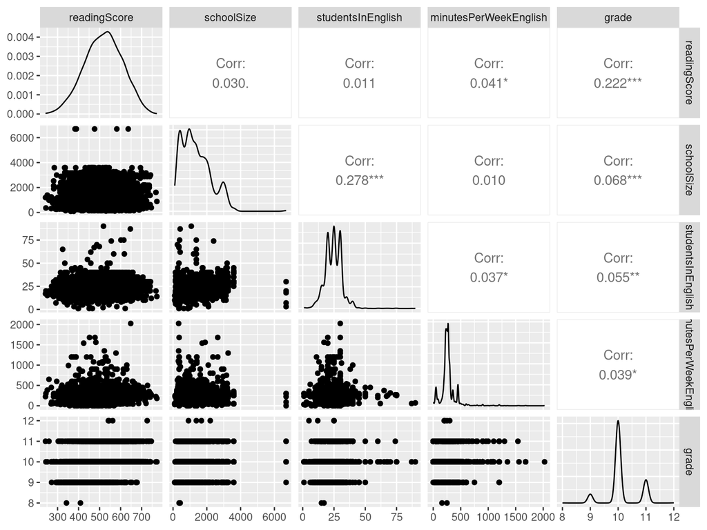

```r
# Analysis
# panel plot
ggpairs(raw_df %>% dplyr::select(c(readingScore, schoolSize, studentsInEnglish, minutesPerWeekEnglish, grade)))
```

Now, let’s look at them individually.

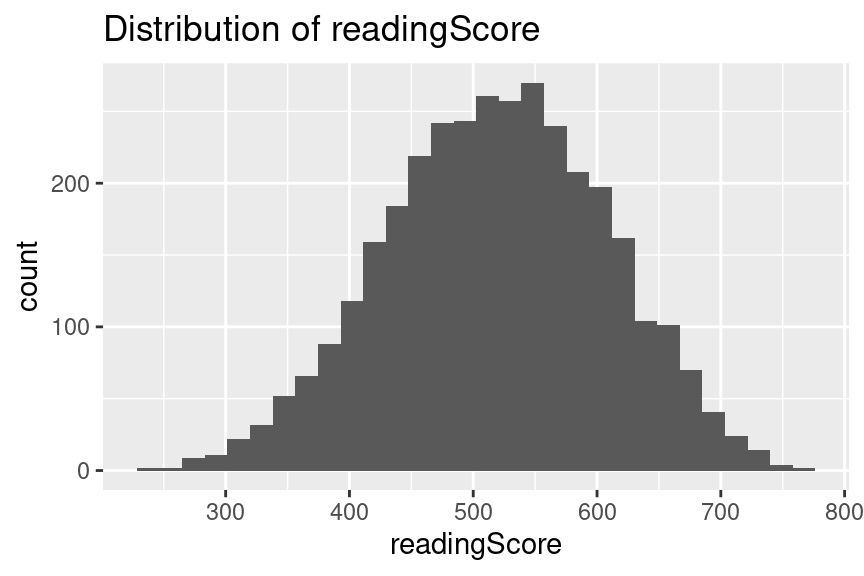

```r
plt_1 <- ggplot(data = raw_df, aes(x = readingScore))
plt_1 + geom_histogram() +
  ggtitle("Distribution of readingScore")
```

From the plot, it looks like the feature is normally distributed.

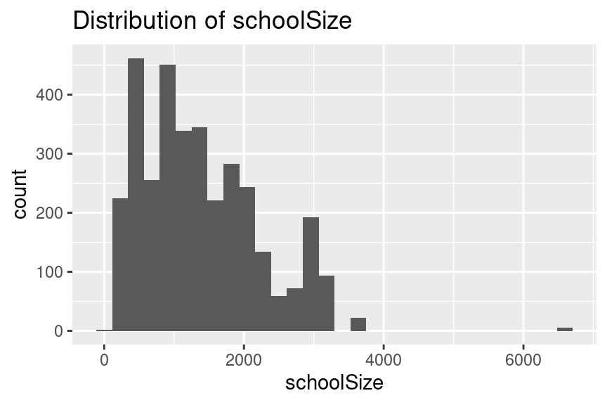

```r
plt_2 <- ggplot(data = raw_df, aes(x = schoolSize))
plt_2 + geom_histogram(bins = 30) +
  ggtitle("Distribution of schoolSize")
```

The feature is not normally distributed. Let’s see if transformation can be helpful here.

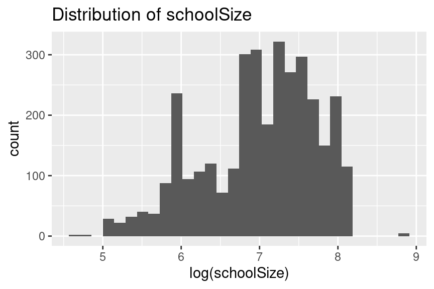

```r
plt_2 <- ggplot(data = raw_df, aes(x = log(schoolSize)))
plt_2 + geom_histogram(bins = 30) +
  ggtitle("Distribution of schoolSize")
```

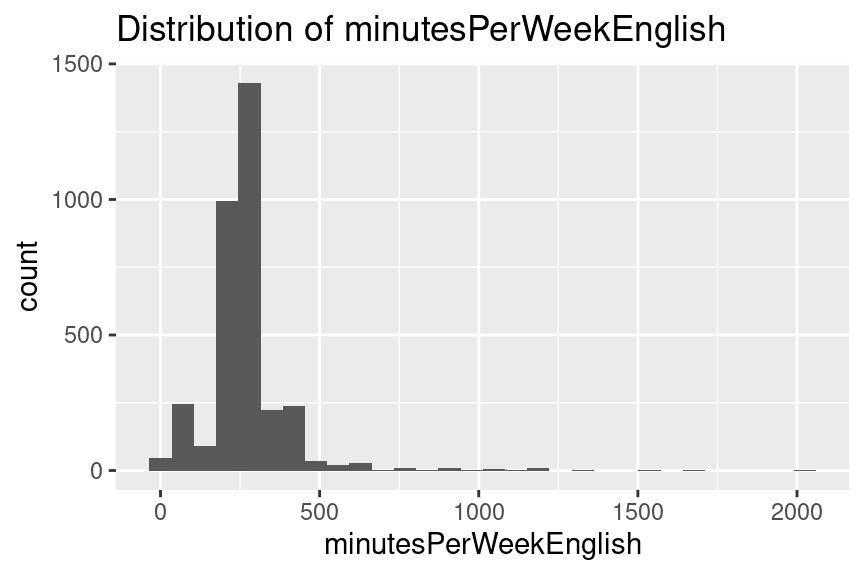

```r
plt_3 <- ggplot(data = raw_df, aes(x = minutesPerWeekEnglish))
plt_3 + geom_histogram(bins = 30) +
  ggtitle("Distribution of minutesPerWeekEnglish")
```

Distribution of minutesPerWeekEnglish is positive skewed.

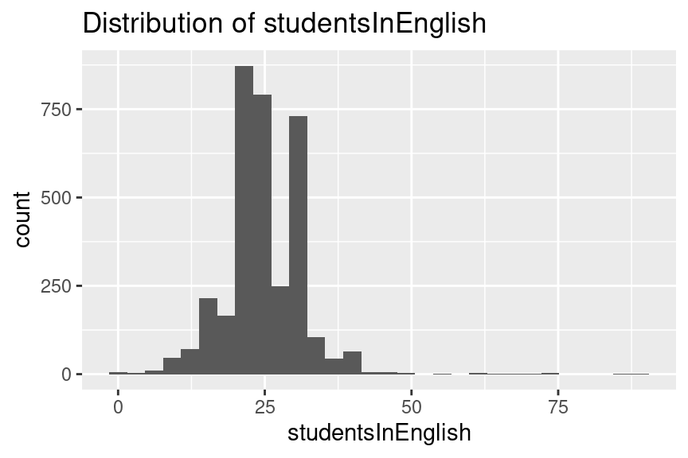

```r
plt_4 <- ggplot(data = raw_df, aes(x = studentsInEnglish))
plt_4 + geom_histogram() +
  ggtitle("Distribution of studentsInEnglish")
```

Distribution of studentsInEnglish is positive skewed.

Let’s look at bivariate analysis.

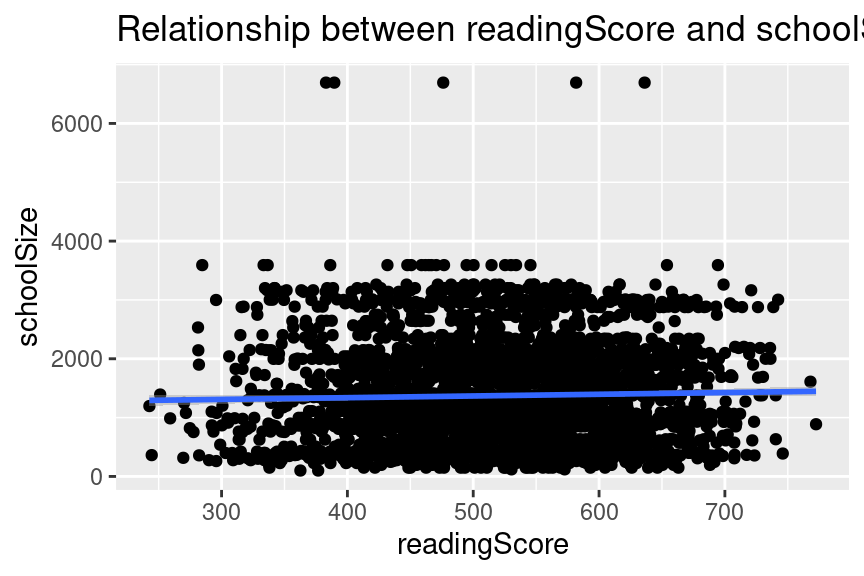

```r
plt_5 <- ggplot(data = raw_df, aes(x = readingScore, y = schoolSize))
plt_5 + geom_point() +
  geom_smooth(method = "lm") +
  ggtitle("Relationship between readingScore and schoolSize")
```

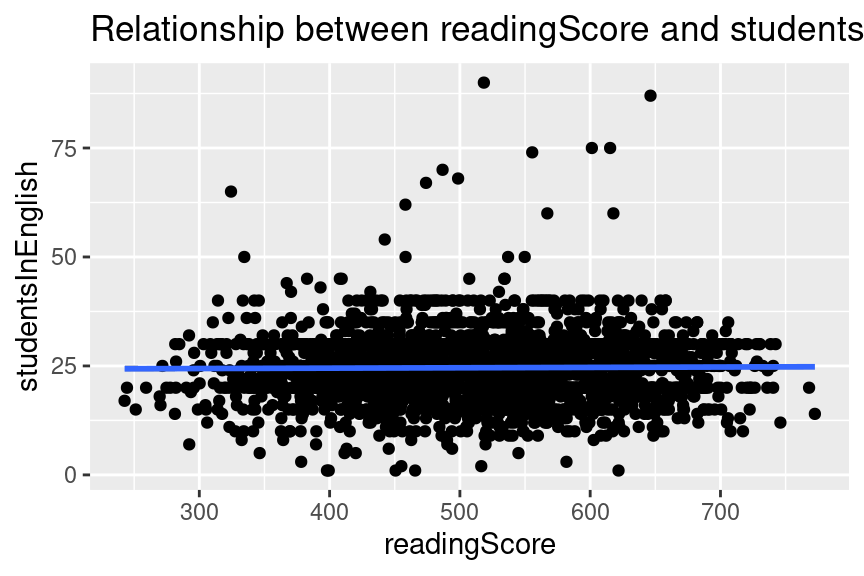

```r
plt_6 <- ggplot(data = raw_df, aes(x = readingScore, y = studentsInEnglish))
plt_6 + geom_point() +
  geom_smooth(method = "lm") +
  ggtitle("Relationship between readingScore and studentsInEnglish")
```

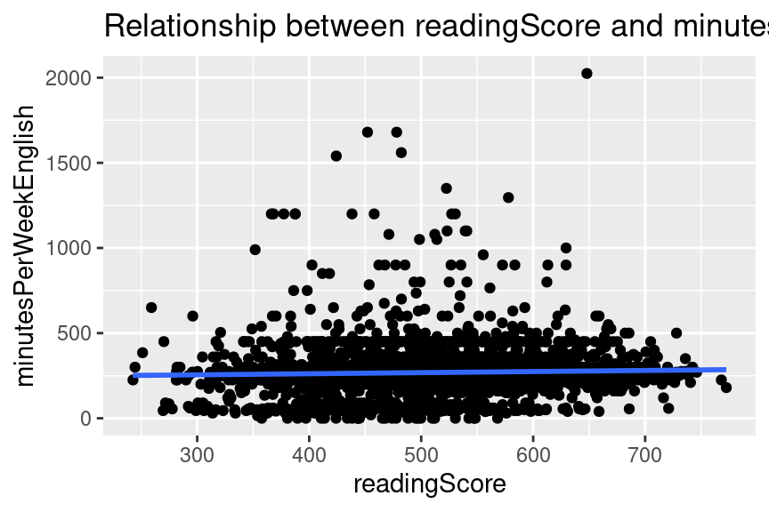

```r
plt_5 <- ggplot(data = raw_df, aes(x = readingScore, y = minutesPerWeekEnglish))
plt_5 + geom_point() +
  geom_smooth(method = "lm") +
  ggtitle("Relationship between readingScore and minutesPerWeekEnglish")
```

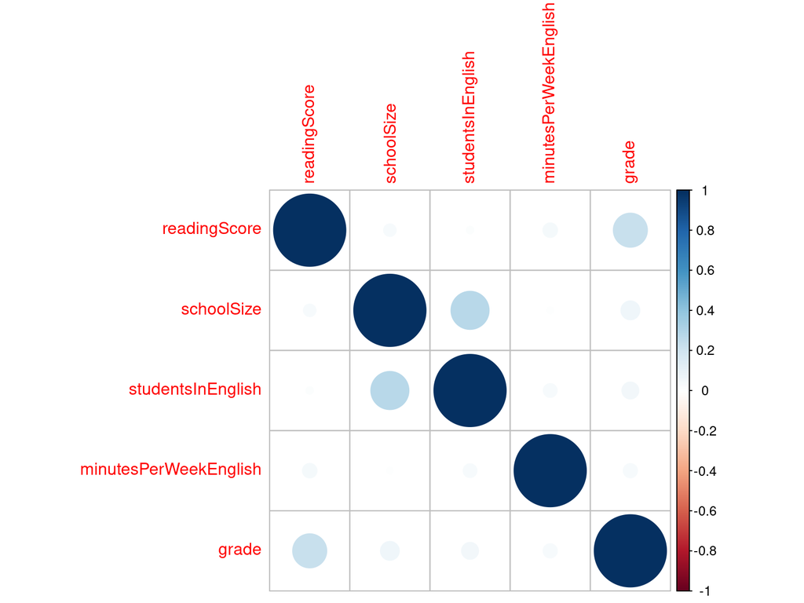

```r
corrplot(corr = cor(raw_df %>% dplyr::select(c(readingScore, schoolSize, studentsInEnglish, minutesPerWeekEnglish, grade))))
```

Let’s see if there’s any relationship on different levels of data.

```r
raw_df <- raw_df %>% mutate(male = as.factor(male),
                            preschool = as.factor(preschool),
                            expectBachelors = as.factor(expectBachelors),
                            motherHS = as.factor(motherHS),
                            englishAtHome = as.factor(englishAtHome),
                            read30MinsADay = as.factor(read30MinsADay),
                            urban = as.factor(urban),
                            publicSchool = as.factor(publicSchool),
                            schoolHasLibrary = as.factor(schoolHasLibrary),
                            computerForSchoolwork = as.factor(computerForSchoolwork),
                            fatherBornUS = as.factor(fatherBornUS),
                            motherBornUS = as.factor(motherBornUS),
                            selfBornUS = as.factor(selfBornUS))
```

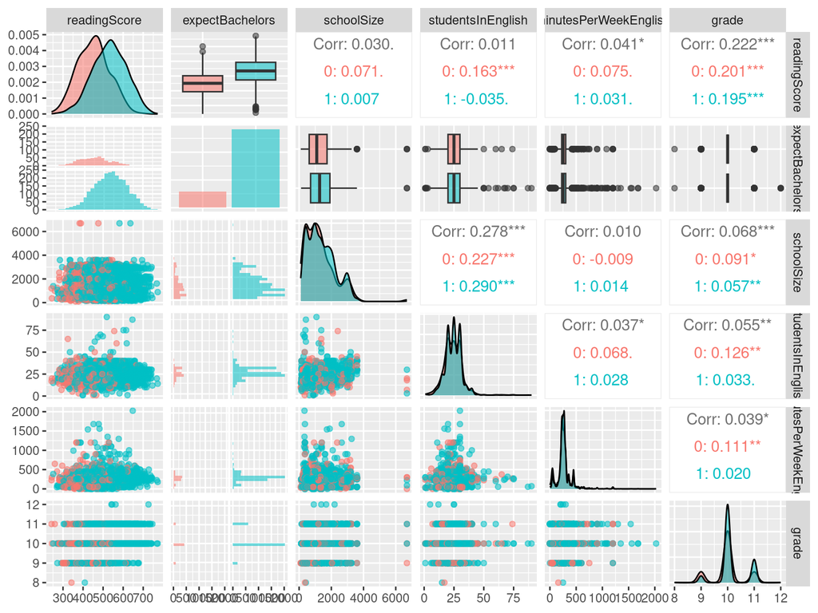

```r
ggpairs(raw_df %>% dplyr::select(c(readingScore, expectBachelors, schoolSize, studentsInEnglish, minutesPerWeekEnglish, grade)), aes(color = expectBachelors, alpha = .5))
```

There is some relationship dependency on expectBachelors on the outcome as well as other features.

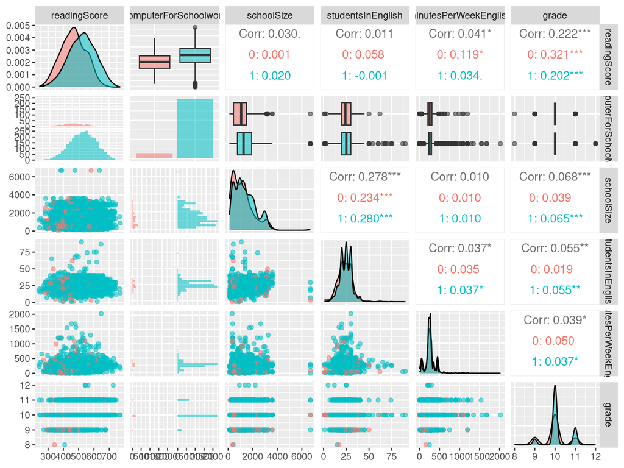

```r
ggpairs(raw_df %>% dplyr::select(c(readingScore, computerForSchoolwork, schoolSize, studentsInEnglish, minutesPerWeekEnglish, grade)), aes(color = computerForSchoolwork, alpha = .5))
```

There is a little impact of computerForSchoolwork on readingScore.

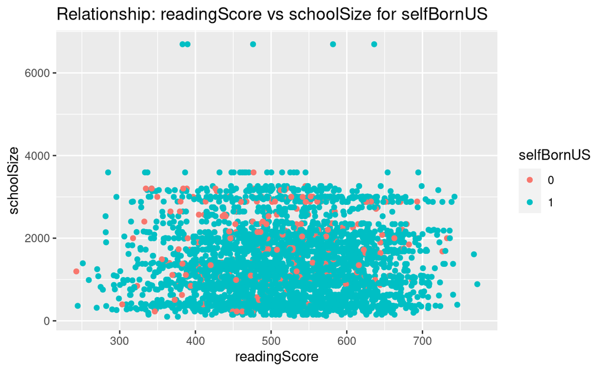

```r
plt_7 <- ggplot(data = raw_df, aes(x = readingScore,
                                   y = schoolSize, color = selfBornUS))
plt_7 + geom_point() +
  ggtitle("Relationship: readingScore vs schoolSize for selfBornUS")
```

#### c. Check for multicolinearity.

```r
# baseline full model
base_model <- lm(readingScore ~., data = train_set)

summary(base_model)
```

```
##
## Call:
## lm(formula = readingScore ~ ., data = train_set)
##
## Residuals:
##      Min       1Q   Median       3Q      Max
## -244.144  -49.911    0.659   49.772  251.302
##
## Coefficients:
##                                                 Estimate Std. Error t value
## (Intercept)                                   110.318730  36.452924   3.026
## grade                                          26.299023   2.907728   9.045
## male                                          -14.189449   3.057169  -4.641
## raceethAsian                                   59.566236  18.899947   3.152
## raceethBlack                                   -6.127478  17.503510  -0.350
## raceethHispanic                                28.345591  17.396011   1.629
## raceethMore than one race                      42.199300  18.733395   2.253
## raceethNative Hawaiian/Other Pacific Islander  48.788656  23.736501   2.055
## raceethWhite                                   61.318604  16.961424   3.615
## preschool                                      -2.219430   3.437682  -0.646
## expectBachelors                                53.656591   4.158338  12.903
## motherHS                                        4.101488   5.842642   0.702
## motherBachelors                                11.841291   3.807703   3.110
## motherWork                                     -2.362730   3.431759  -0.688
## fatherHS                                        7.526356   5.412362   1.391
## fatherBachelors                                15.719702   3.952976   3.977
## fatherWork                                      5.849905   4.306192   1.358
## selfBornUS                                      8.106854   6.946375   1.167
## motherBornUS                                   -1.177879   6.649228  -0.177
## fatherBornUS                                    1.183191   6.345862   0.186
## englishAtHome                                   5.412647   6.766097   0.800
## computerForSchoolwork                          23.591662   5.461050   4.320
## read30MinsADay                                 31.180348   3.306728   9.429
## minutesPerWeekEnglish                           0.003159   0.010806   0.292
## studentsInEnglish                               0.014926   0.218353   0.068
## schoolHasLibrary                               -2.039406   8.828358  -0.231
## publicSchool                                  -16.236095   6.515302  -2.492
## urban                                          -1.397513   3.857402  -0.362
## schoolSize                                      0.007000   0.002108   3.321
##                                                           Pr(>|t|)
```

[output cut: 20 more lines]

```
## englishAtHome                                             0.423806
## computerForSchoolwork                                   0.00001621 ***
## read30MinsADay                                < 0.0000000000000002 ***
## minutesPerWeekEnglish                                     0.770032
## studentsInEnglish                                         0.945505
## schoolHasLibrary                                          0.817329
## publicSchool                                              0.012766 *
## urban                                                     0.717163
## schoolSize                                                0.000910 ***
## ---
## Signif. codes:  0 '***' 0.001 '**' 0.01 '*' 0.05 '.' 0.1 ' ' 1
##
## Residual standard error: 74.32 on 2526 degrees of freedom
## Multiple R-squared:  0.3087, Adjusted R-squared:  0.301
## F-statistic: 40.28 on 28 and 2526 DF,  p-value: < 0.00000000000000022
```

```r
vif(base_model)
```

```
##                                         grade
##                                        1.0530
##                                          male
##                                        1.0807
##                                  raceethAsian
##                                        7.0435
##                                  raceethBlack
##                                       12.1970
##                               raceethHispanic
##                                       22.3640
##                     raceethMore than one race
##                                        4.9832
## raceethNative Hawaiian/Other Pacific Islander
##                                        2.1245
##                                  raceethWhite
##                                       31.5720
##                                     preschool
##                                        1.0844
##                               expectBachelors
##                                        1.1402
##                                      motherHS
##                                        1.5021
##                               motherBachelors
##                                        1.5287
##                                    motherWork
##                                        1.0670
##                                      fatherHS
##                                        1.4885
##                               fatherBachelors
##                                        1.6066
##                                    fatherWork
##                                        1.0647
##                                    selfBornUS
##                                        1.4841
##                                  motherBornUS
##                                        3.4227
##                                  fatherBornUS
##                                        3.1467
##                                 englishAtHome
##                                        2.2952
##                         computerForSchoolwork
##                                        1.1300
##                                read30MinsADay
##                                        1.0688
##                         minutesPerWeekEnglish
##                                        1.0177
##                             studentsInEnglish
##                                        1.1173
##                              schoolHasLibrary
##                                        1.0405
##                                  publicSchool
##                                        1.5260
##                                         urban
##                                        1.5852
##                                    schoolSize
##                                        1.4996
```

```r
model_1 <- lm(readingScore~ grade +male+ expectBachelors +motherBachelors +fatherHS
+fatherBachelors +fatherWork +englishAtHome +computerForSchoolwork
+read30MinsADay+publicSchool +urban +schoolSize, data=train_set)

summary(model_1)
```

```
##
## Call:
## lm(formula = readingScore ~ grade + male + expectBachelors +
##     motherBachelors + fatherHS + fatherBachelors + fatherWork +
##     englishAtHome + computerForSchoolwork + read30MinsADay +
##     publicSchool + urban + schoolSize, data = train_set)
##
## Residuals:
##      Min       1Q   Median       3Q      Max
## -252.728  -51.071    1.144   51.886  265.919
##
## Coefficients:
##                         Estimate Std. Error t value             Pr(>|t|)
## (Intercept)           145.281021  31.551819   4.605          0.000004338 ***
## grade                  26.999025   2.992902   9.021 < 0.0000000000000002 ***
## male                  -13.313834   3.152914  -4.223          0.000024987 ***
## expectBachelors        52.428685   4.275844  12.262 < 0.0000000000000002 ***
## motherBachelors        11.788834   3.882002   3.037              0.00242 **
## fatherHS               13.447016   5.112980   2.630              0.00859 **
## fatherBachelors        22.179897   4.033426   5.499          0.000000042 ***
## fatherWork              9.456408   4.398395   2.150              0.03165 *
## englishAtHome          16.026786   5.072250   3.160              0.00160 **
## computerForSchoolwork  27.524194   5.578620   4.934          0.000000858 ***
## read30MinsADay         32.996293   3.409510   9.678 < 0.0000000000000002 ***
## publicSchool          -23.966051   6.634978  -3.612              0.00031 ***
## urban                 -11.010346   3.834496  -2.871              0.00412 **
## schoolSize              0.006549   0.002112   3.101              0.00195 **
## ---
## Signif. codes:  0 '***' 0.001 '**' 0.01 '*' 0.05 '.' 0.1 ' ' 1
##
## Residual standard error: 76.99 on 2541 degrees of freedom
## Multiple R-squared:  0.2537, Adjusted R-squared:  0.2499
## F-statistic: 66.46 on 13 and 2541 DF,  p-value: < 0.00000000000000022
```

```r
vif(model_1)
```

```
##                 grade                  male       expectBachelors
##                1.0396                1.0712                1.1234
##       motherBachelors              fatherHS       fatherBachelors
##                1.4807                1.2379                1.5586
##            fatherWork         englishAtHome computerForSchoolwork
##                1.0350                1.2020                1.0989
##        read30MinsADay          publicSchool                 urban
##                1.0589                1.4748                1.4597
##            schoolSize
##                1.4027
```

Since most of the values are closer to 1, multicolinearity might not be a problematic.

#### d. Create appropriate dummy variables.

Since a lot of features are represented as 1s and 0s, we will convert their representation to ‘Y’ and ‘N’ respectively.

```r
train_set <- train_set %>%
  mutate(male = if_else(male == 1, "Y", "N"),
         preschool = if_else(preschool == 1, "Y", "N"),
         expectBachelors = if_else(expectBachelors == 1, "Y", "N"),
         motherHS = if_else(motherHS == 1, "Y", "N"),
         motherBachelors = if_else(motherBachelors == 1, "Y", "N"),
         motherWork = if_else(motherWork == 1, "Y", "N"),
         fatherHS = if_else(fatherHS==1, "Y", "N"),
         fatherBachelors = if_else(fatherBachelors ==1, "Y", "N"),
         fatherBornUS = if_else(fatherBornUS == 1, "Y", "N"),
         fatherWork = if_else(fatherWork == 1, "Y", "N"),
         selfBornUS = if_else(selfBornUS == 1, "Y", "N"),
         motherBornUS = if_else(motherBornUS ==1, "Y", "N"),
         englishAtHome = if_else(englishAtHome ==1, "Y", "N"),
         computerForSchoolwork = if_else(computerForSchoolwork ==1, "Y", "N"),
         read30MinsADay = if_else(read30MinsADay ==1, "Y", "N"),
         schoolHasLibrary = if_else(schoolHasLibrary ==1, "Y", "N"),
         publicSchool = if_else(publicSchool ==1, "Y", "N"),
         urban = if_else(urban ==1, "Y", "N"))

test_set <- test_set %>%
  mutate(male = if_else(male == 1, "Y", "N"),
         preschool = if_else(preschool == 1, "Y", "N"),
         expectBachelors = if_else(expectBachelors == 1, "Y", "N"),
         motherHS = if_else(motherHS == 1, "Y", "N"),
         motherBachelors = if_else(motherBachelors == 1, "Y", "N"),
         motherWork = if_else(motherWork == 1, "Y", "N"),
         fatherHS = if_else(fatherHS==1, "Y", "N"),
         fatherBachelors = if_else(fatherBachelors ==1, "Y", "N"),
         fatherBornUS = if_else(fatherBornUS == 1, "Y", "N"),
         fatherWork = if_else(fatherWork == 1, "Y", "N"),
         selfBornUS = if_else(selfBornUS == 1, "Y", "N"),
         motherBornUS = if_else(motherBornUS ==1, "Y", "N"),
         englishAtHome = if_else(englishAtHome ==1, "Y", "N"),
         computerForSchoolwork = if_else(computerForSchoolwork ==1, "Y", "N"),
         read30MinsADay = if_else(read30MinsADay ==1, "Y", "N"),
         schoolHasLibrary = if_else(schoolHasLibrary ==1, "Y", "N"),
         publicSchool = if_else(publicSchool ==1, "Y", "N"),
         urban = if_else(urban ==1, "Y", "N"))
```

#### e. Perform feature selection.

```r
# full model
full_model <- lm(readingScore~., data = train_set)

# step wise selection
step <- stepAIC(full_model, direction="backward")
```

```r
# stepwise anova
step$anova
```

```
## Stepwise Model Path
## Analysis of Deviance Table
##
## Initial Model:
## readingScore ~ grade + male + raceeth + preschool + expectBachelors +
##     motherHS + motherBachelors + motherWork + fatherHS + fatherBachelors +
##     fatherWork + selfBornUS + motherBornUS + fatherBornUS + englishAtHome +
##     computerForSchoolwork + read30MinsADay + minutesPerWeekEnglish +
##     studentsInEnglish + schoolHasLibrary + publicSchool + urban +
##     schoolSize
##
## Final Model:
## readingScore ~ grade + male + raceeth + expectBachelors + motherBachelors +
##     fatherHS + fatherBachelors + selfBornUS + computerForSchoolwork +
##     read30MinsADay + publicSchool + schoolSize
##
##
##                       Step Df   Deviance Resid. Df Resid. Dev      AIC
## 1                                             2526   13952372 22044.68
## 2      - studentsInEnglish  1   25.81105      2527   13952398 22042.68
## 3           - motherBornUS  1  176.45030      2528   13952574 22040.71
## 4           - fatherBornUS  1   73.71590      2529   13952648 22038.73
## 5       - schoolHasLibrary  1  290.33363      2530   13952938 22036.78
## 6  - minutesPerWeekEnglish  1  463.76785      2531   13953402 22034.86
## 7                  - urban  1  630.45610      2532   13954033 22032.98
## 8              - preschool  1 2229.17864      2533   13956262 22031.39
## 9               - motherHS  1 2527.66373      2534   13958790 22029.85
## 10            - motherWork  1 2274.35773      2535   13961064 22028.27
## 11         - englishAtHome  1 4923.95146      2536   13965988 22027.17
## 12            - fatherWork  1 8546.23450      2537   13974534 22026.73
```

```r
# final model
final_model <- lm(readingScore~grade + male + raceeth + expectBachelors + motherBachelors +
    fatherHS + fatherBachelors + selfBornUS + computerForSchoolwork +
    read30MinsADay + publicSchool + schoolSize, data = train_set)

summary(final_model)
```

```
##
## Call:
## lm(formula = readingScore ~ grade + male + raceeth + expectBachelors +
##     motherBachelors + fatherHS + fatherBachelors + selfBornUS +
##     computerForSchoolwork + read30MinsADay + publicSchool + schoolSize,
##     data = train_set)
##
## Residuals:
##      Min       1Q   Median       3Q      Max
## -250.599  -49.338    0.729   49.258  244.899
##
## Coefficients:
##                                                 Estimate Std. Error t value
## (Intercept)                                   112.196678  34.777916   3.226
## grade                                          26.342209   2.892557   9.107
## maleY                                         -14.089855   3.045338  -4.627
## raceethAsian                                   58.231893  18.333318   3.176
## raceethBlack                                   -6.105821  17.424276  -0.350
## raceethHispanic                                27.375108  17.097481   1.601
## raceethMore than one race                      43.366625  18.641659   2.326
## raceethNative Hawaiian/Other Pacific Islander  49.328591  23.390490   2.109
## raceethWhite                                   62.475468  16.878969   3.701
## expectBachelorsY                               53.587180   4.131702  12.970
## motherBachelorsY                               11.771465   3.747405   3.141
## fatherHSY                                       9.920856   4.910485   2.020
## fatherBachelorsY                               16.186392   3.918596   4.131
## selfBornUSY                                    10.500697   6.114582   1.717
## computerForSchoolworkY                         24.176886   5.373781   4.499
## read30MinsADayY                                31.402192   3.286236   9.556
## publicSchoolY                                 -14.533215   5.733703  -2.535
## schoolSize                                      0.006556   0.001887   3.474
##                                                           Pr(>|t|)
## (Intercept)                                               0.001271 **
## grade                                         < 0.0000000000000002 ***
## maleY                                                   0.00000390 ***
## raceethAsian                                              0.001510 **
## raceethBlack                                              0.726052
## raceethHispanic                                           0.109475
## raceethMore than one race                                 0.020079 *
## raceethNative Hawaiian/Other Pacific Islander             0.035050 *
## raceethWhite                                              0.000219 ***
## expectBachelorsY                              < 0.0000000000000002 ***
## motherBachelorsY                                          0.001702 **
## fatherHSY                                                 0.043453 *
## fatherBachelorsY                                        0.00003734 ***
## selfBornUSY                                               0.086043 .
## computerForSchoolworkY                                  0.00000713 ***
## read30MinsADayY                               < 0.0000000000000002 ***
## publicSchoolY                                             0.011314 *
## schoolSize                                                0.000521 ***
## ---
## Signif. codes:  0 '***' 0.001 '**' 0.01 '*' 0.05 '.' 0.1 ' ' 1
##
## Residual standard error: 74.22 on 2537 degrees of freedom
## Multiple R-squared:  0.3076, Adjusted R-squared:  0.303
## F-statistic:  66.3 on 17 and 2537 DF,  p-value: < 0.00000000000000022
```

#### f. Check for appropriate second order terms

```r
# lets see if adding second order terms work
train_set <- train_set %>%
  mutate(minutesPerWeekEnglish_sec_ordr = minutesPerWeekEnglish^2,
         studentsInEnglish_sec_ordr = studentsInEnglish^2,
         schoolSize_sec_ordr = schoolSize^2,
         grade_sec_ordr = grade^2)

test_set <- test_set %>%
  mutate(minutesPerWeekEnglish_sec_ordr = minutesPerWeekEnglish^2,
         studentsInEnglish_sec_ordr = studentsInEnglish^2,
         schoolSize_sec_ordr = schoolSize^2,
         grade_sec_ordr = grade^2)
```

```r
# second order model
sec_ordr_model <- lm(readingScore~., data = train_set)

# use stepwise to determine if second order terms are helpful
step2 <- stepAIC(sec_ordr_model, direction="backward")
```

```r
# anova
step2$anova
```

```
## Stepwise Model Path
## Analysis of Deviance Table
##
## Initial Model:
## readingScore ~ grade + male + raceeth + preschool + expectBachelors +
##     motherHS + motherBachelors + motherWork + fatherHS + fatherBachelors +
##     fatherWork + selfBornUS + motherBornUS + fatherBornUS + englishAtHome +
##     computerForSchoolwork + read30MinsADay + minutesPerWeekEnglish +
##     studentsInEnglish + schoolHasLibrary + publicSchool + urban +
##     schoolSize + minutesPerWeekEnglish_sec_ordr + studentsInEnglish_sec_ordr +
##     schoolSize_sec_ordr + grade_sec_ordr
##
## Final Model:
## readingScore ~ grade + male + raceeth + expectBachelors + motherBachelors +
##     fatherHS + fatherBachelors + englishAtHome + computerForSchoolwork +
##     read30MinsADay + minutesPerWeekEnglish + publicSchool + schoolSize +
##     minutesPerWeekEnglish_sec_ordr + grade_sec_ordr
##
##
##                            Step Df   Deviance Resid. Df Resid. Dev      AIC
## 1                                                  2522   13697536 22005.58
## 2  - studentsInEnglish_sec_ordr  1   48.68733      2523   13697585 22003.59
## 3                       - urban  1  295.02741      2524   13697880 22001.64
## 4            - schoolHasLibrary  1  229.09811      2525   13698109 21999.68
## 5                - fatherBornUS  1  414.44582      2526   13698524 21997.76
## 6                - motherBornUS  1  846.81681      2527   13699370 21995.92
## 7         - schoolSize_sec_ordr  1 1114.42291      2528   13700485 21994.13
## 8           - studentsInEnglish  1 1182.13956      2529   13701667 21992.35
## 9                    - motherHS  1 1796.88042      2530   13703464 21990.68
## 10                 - motherWork  1 2087.73787      2531   13705552 21989.07
## 11                 - selfBornUS  1 2344.63818      2532   13707896 21987.51
## 12                  - preschool  1 3823.08591      2533   13711719 21986.22
## 13                 - fatherWork  1 4890.43977      2534   13716610 21985.13
```

```r
# second order final model
sec_ordr_model <- lm(readingScore ~ grade + male + raceeth + expectBachelors + motherBachelors +  fatherHS + fatherBachelors + englishAtHome + computerForSchoolwork +
    read30MinsADay + minutesPerWeekEnglish + publicSchool + schoolSize +
    minutesPerWeekEnglish_sec_ordr + grade_sec_ordr, data = train_set)

# summary
summary(sec_ordr_model)
```

```
##
## Call:
## lm(formula = readingScore ~ grade + male + raceeth + expectBachelors +
##     motherBachelors + fatherHS + fatherBachelors + englishAtHome +
##     computerForSchoolwork + read30MinsADay + minutesPerWeekEnglish +
##     publicSchool + schoolSize + minutesPerWeekEnglish_sec_ordr +
##     grade_sec_ordr, data = train_set)
##
## Residuals:
##      Min       1Q   Median       3Q      Max
## -250.550  -48.237    0.066   50.315  245.921
##
## Coefficients:
##                                                     Estimate     Std. Error
## (Intercept)                                   -1478.28670991   344.73010752
## grade                                           337.90307047    67.76528707
## maleY                                           -14.40246752     3.02063430
## raceethAsian                                     61.32368307    18.20556869
## raceethBlack                                     -2.68306881    17.28769432
## raceethHispanic                                  32.52963506    17.01197796
## raceethMore than one race                        44.42595946    18.49092033
## raceethNative Hawaiian/Other Pacific Islander    51.02064386    23.18858357
## raceethWhite                                     63.30515499    16.74034196
## expectBachelorsY                                 51.50131746     4.10681195
## motherBachelorsY                                 11.92024666     3.71619453
## fatherHSY                                         7.94369283     4.95382987
## fatherBachelorsY                                 15.91549705     3.88203812
## englishAtHomeY                                    8.51268452     5.48030837
## computerForSchoolworkY                           21.85730716     5.34295890
## read30MinsADayY                                  31.33117315     3.26146858
## minutesPerWeekEnglish                             0.10663634     0.02351391
## publicSchoolY                                   -15.88989473     5.69056616
## schoolSize                                        0.00655435     0.00187676
## minutesPerWeekEnglish_sec_ordr                   -0.00010771     0.00002148
## grade_sec_ordr                                  -15.32953861     3.32784099
##                                               t value             Pr(>|t|)
## (Intercept)                                    -4.288          0.000018683 ***
## grade                                           4.986          0.000000657 ***
## maleY                                          -4.768          0.000001966 ***
## raceethAsian                                    3.368             0.000767 ***
```

[output cut: 8 more lines]

```
## fatherBachelorsY                                4.100          0.000042656 ***
## englishAtHomeY                                  1.553             0.120471
## computerForSchoolworkY                          4.091          0.000044319 ***
## read30MinsADayY                                 9.606 < 0.0000000000000002 ***
## minutesPerWeekEnglish                           4.535          0.000006027 ***
## publicSchoolY                                  -2.792             0.005272 **
## schoolSize                                      3.492             0.000487 ***
## minutesPerWeekEnglish_sec_ordr                 -5.014          0.000000570 ***
## grade_sec_ordr                                 -4.606          0.000004299 ***
## ---
## Signif. codes:  0 '***' 0.001 '**' 0.01 '*' 0.05 '.' 0.1 ' ' 1
##
## Residual standard error: 73.57 on 2534 degrees of freedom
## Multiple R-squared:  0.3204, Adjusted R-squared:  0.315
## F-statistic: 59.73 on 20 and 2534 DF,  p-value: < 0.00000000000000022
```

#### g. Check for appropriate interaction terms.

```r
# create interaction terms
train_set <- train_set %>%
  mutate(grade_mins = grade*minutesPerWeekEnglish,
         grade_en_stu = grade * studentsInEnglish,
         grade_school_size = grade*schoolSize,
         mins_stu = minutesPerWeekEnglish * studentsInEnglish,
         mins_sch = minutesPerWeekEnglish * schoolSize,
         stu_sch = studentsInEnglish * schoolSize)

test_set <- test_set %>%
  mutate(grade_mins = grade*minutesPerWeekEnglish,
         grade_en_stu = grade * studentsInEnglish,
         grade_school_size = grade*schoolSize,
         mins_stu = minutesPerWeekEnglish * studentsInEnglish,
         mins_sch = minutesPerWeekEnglish * schoolSize,
         stu_sch = studentsInEnglish * schoolSize)
```

```r
# interction model
interaction_model <- lm(readingScore ~ grade + male + raceeth + expectBachelors +
    motherBachelors + fatherHS + fatherBachelors  +
    computerForSchoolwork + read30MinsADay  +
    publicSchool  + minutesPerWeekEnglish_sec_ordr +
    grade_sec_ordr + grade_mins + grade_en_stu + grade_school_size + mins_stu + mins_sch + stu_sch, data = train_set)

# summary
summary(interaction_model)
```

```
##
## Call:
## lm(formula = readingScore ~ grade + male + raceeth + expectBachelors +
##     motherBachelors + fatherHS + fatherBachelors + computerForSchoolwork +
##     read30MinsADay + publicSchool + minutesPerWeekEnglish_sec_ordr +
##     grade_sec_ordr + grade_mins + grade_en_stu + grade_school_size +
##     mins_stu + mins_sch + stu_sch, data = train_set)
##
## Residuals:
##      Min       1Q   Median       3Q      Max
## -249.471  -49.279   -0.038   50.065  243.860
##
## Coefficients:
##                                                        Estimate
## (Intercept)                                   -1456.57702116484
## grade                                           338.50383268599
## maleY                                           -14.44079815528
## raceethAsian                                     58.58302211857
## raceethBlack                                     -1.72802621837
## raceethHispanic                                  30.73750806676
## raceethMore than one race                        45.62692737231
## raceethNative Hawaiian/Other Pacific Islander    51.67539864935
## raceethWhite                                     64.42006867333
## expectBachelorsY                                 51.59064017327
## motherBachelorsY                                 12.03258068079
## fatherHSY                                         9.49327817879
## fatherBachelorsY                                 15.79837457018
## computerForSchoolworkY                           22.22540463416
## read30MinsADayY                                  31.28681417252
## publicSchoolY                                   -15.76440663238
## minutesPerWeekEnglish_sec_ordr                   -0.00010995130
## grade_sec_ordr                                  -15.44376924179
## grade_mins                                        0.00820285230
## grade_en_stu                                     -0.04504544198
## grade_school_size                                 0.00046284856
## mins_stu                                          0.00108163566
## mins_sch                                          0.00000006824
## stu_sch                                           0.00006540374
##                                                      Std. Error t value
## (Intercept)                                     345.54295906944  -4.215
```

[output cut: 39 more lines]

```
## publicSchoolY                                             0.005828 **
## minutesPerWeekEnglish_sec_ordr                         0.000000635 ***
## grade_sec_ordr                                         0.000003802 ***
## grade_mins                                                0.082976 .
## grade_en_stu                                              0.378549
## grade_school_size                                         0.473637
## mins_stu                                                  0.492065
## mins_sch                                                  0.995621
## stu_sch                                                   0.764009
## ---
## Signif. codes:  0 '***' 0.001 '**' 0.01 '*' 0.05 '.' 0.1 ' ' 1
##
## Residual standard error: 73.64 on 2531 degrees of freedom
## Multiple R-squared:   0.32,  Adjusted R-squared:  0.3139
## F-statistic: 51.79 on 23 and 2531 DF,  p-value: < 0.00000000000000022
```

Looks like only 1 interaction term is significant in this model. Let’s try stepwise model.

```r
# full model
full_model <- lm(readingScore~., data = train_set)

# stepwise
step_3 <- stepAIC(full_model, direction = "backward")
```

```r
step_3$anova
```

```
## Stepwise Model Path
## Analysis of Deviance Table
##
## Initial Model:
## readingScore ~ grade + male + raceeth + preschool + expectBachelors +
##     motherHS + motherBachelors + motherWork + fatherHS + fatherBachelors +
##     fatherWork + selfBornUS + motherBornUS + fatherBornUS + englishAtHome +
##     computerForSchoolwork + read30MinsADay + minutesPerWeekEnglish +
##     studentsInEnglish + schoolHasLibrary + publicSchool + urban +
##     schoolSize + minutesPerWeekEnglish_sec_ordr + studentsInEnglish_sec_ordr +
##     schoolSize_sec_ordr + grade_sec_ordr + grade_mins + grade_en_stu +
##     grade_school_size + mins_stu + mins_sch + stu_sch
##
## Final Model:
## readingScore ~ grade + male + raceeth + expectBachelors + motherBachelors +
##     fatherHS + fatherBachelors + englishAtHome + computerForSchoolwork +
##     read30MinsADay + publicSchool + schoolSize + minutesPerWeekEnglish_sec_ordr +
##     grade_sec_ordr + grade_mins
##
##
##                            Step Df   Deviance Resid. Df Resid. Dev      AIC
## 1                                                  2516   13682057 22014.69
## 2                    - mins_sch  1   41.99701      2517   13682099 22012.70
## 3                     - stu_sch  1  137.05068      2518   13682236 22010.72
## 4            - schoolHasLibrary  1  138.27928      2519   13682374 22008.75
## 5                       - urban  1  282.18117      2520   13682656 22006.80
## 6  - studentsInEnglish_sec_ordr  1  311.94986      2521   13682968 22004.86
## 7                - fatherBornUS  1  328.41413      2522   13683297 22002.92
## 8                - motherBornUS  1  975.60478      2523   13684272 22001.10
## 9         - schoolSize_sec_ordr  1 1175.75120      2524   13685448 21999.32
## 10                   - motherHS  1 1230.11597      2525   13686678 21997.55
## 11          - studentsInEnglish  1 1506.94604      2526   13688185 21995.83
## 12                 - motherWork  1 1861.90960      2527   13690047 21994.18
## 13      - minutesPerWeekEnglish  1 2347.54587      2528   13692395 21992.62
## 14                   - mins_stu  1 1983.61149      2529   13694378 21990.99
## 15               - grade_en_stu  1 1444.99252      2530   13695823 21989.26
## 16                 - selfBornUS  1 2176.40053      2531   13698000 21987.66
## 17                  - preschool  1 3539.96890      2532   13701540 21986.32
## 18                 - fatherWork  1 4907.45731      2533   13706447 21985.24
## 19          - grade_school_size  1 6075.27364      2534   13712522 21984.37
```

#### h. Transform variables as needed

We can try some log transformation on the continuous features to see if it affects the model performance.

```r
train_set <- train_set %>%
  mutate(minutesPerWeekEnglish_log = log(minutesPerWeekEnglish+1),
         studentsInEnglish_log = log(studentsInEnglish+1),
         schoolSize_log = log(schoolSize+1))

test_set <- test_set %>%
  mutate(minutesPerWeekEnglish_log = log(minutesPerWeekEnglish+1),
         studentsInEnglish_log = log(studentsInEnglish+1),
         schoolSize_log = log(schoolSize+1))
```

```r
# model
transform_model <- lm(readingScore~grade + male + raceeth + expectBachelors + motherBachelors +
    fatherHS + fatherBachelors + englishAtHome + computerForSchoolwork +
    read30MinsADay + publicSchool + schoolSize + minutesPerWeekEnglish_sec_ordr +
    grade_sec_ordr + grade_mins + minutesPerWeekEnglish_log + studentsInEnglish_log + schoolSize_log, data = train_set)

summary(transform_model)
```

```
##
## Call:
## lm(formula = readingScore ~ grade + male + raceeth + expectBachelors +
##     motherBachelors + fatherHS + fatherBachelors + englishAtHome +
##     computerForSchoolwork + read30MinsADay + publicSchool + schoolSize +
##     minutesPerWeekEnglish_sec_ordr + grade_sec_ordr + grade_mins +
##     minutesPerWeekEnglish_log + studentsInEnglish_log + schoolSize_log,
##     data = train_set)
##
## Residuals:
##     Min      1Q  Median      3Q     Max
## -252.43  -48.09    0.83   50.12  243.66
##
## Coefficients:
##                                                     Estimate     Std. Error
## (Intercept)                                   -1506.87496926   345.68050795
## grade                                           335.72147198    67.80184391
## maleY                                           -14.26308749     3.02143329
## raceethAsian                                     59.89532499    18.21471370
## raceethBlack                                     -3.61056989    17.31724119
## raceethHispanic                                  31.20311513    17.01683126
## raceethMore than one race                        43.61835144    18.49943306
## raceethNative Hawaiian/Other Pacific Islander    49.54157185    23.19056162
## raceethWhite                                     61.91729120    16.75005699
## expectBachelorsY                                 51.48060450     4.10978784
## motherBachelorsY                                 11.77882659     3.71466389
## fatherHSY                                         8.00901259     4.95551155
## fatherBachelorsY                                 15.82496432     3.88937781
## englishAtHomeY                                    8.51119847     5.47864953
## computerForSchoolworkY                           21.00248059     5.36578819
## read30MinsADayY                                  31.42649438     3.26163205
## publicSchoolY                                   -14.94239353     5.75501771
## schoolSize                                        0.00489009     0.00461458
## minutesPerWeekEnglish_sec_ordr                   -0.00006710     0.00002836
## grade_sec_ordr                                  -15.26197557     3.32887971
## grade_mins                                        0.00320868     0.00395970
## minutesPerWeekEnglish_log                         9.24626342     3.89438808
## studentsInEnglish_log                            -0.08376898     5.03646997
## schoolSize_log                                    1.90079314     5.48077415
##                                               t value             Pr(>|t|)
```

[output cut: 15 more lines]

```
## read30MinsADayY                                 9.635 < 0.0000000000000002 ***
## publicSchoolY                                  -2.596             0.009475 **
## schoolSize                                      1.060             0.289380
## minutesPerWeekEnglish_sec_ordr                 -2.366             0.018071 *
## grade_sec_ordr                                 -4.585          0.000004767 ***
## grade_mins                                      0.810             0.417824
## minutesPerWeekEnglish_log                       2.374             0.017659 *
## studentsInEnglish_log                          -0.017             0.986731
## schoolSize_log                                  0.347             0.728762
## ---
## Signif. codes:  0 '***' 0.001 '**' 0.01 '*' 0.05 '.' 0.1 ' ' 1
##
## Residual standard error: 73.52 on 2531 degrees of freedom
## Multiple R-squared:  0.3221, Adjusted R-squared:  0.3159
## F-statistic: 52.29 on 23 and 2531 DF,  p-value: < 0.00000000000000022
```

```r
# transform full
transform_full <- lm(readingScore~., data = train_set)

# stepwise model
step_4 <- stepAIC(transform_full, direction = "backward")
```

```r
step_4$anova
```

```
## Stepwise Model Path
## Analysis of Deviance Table
##
## Initial Model:
## readingScore ~ grade + male + raceeth + preschool + expectBachelors +
##     motherHS + motherBachelors + motherWork + fatherHS + fatherBachelors +
##     fatherWork + selfBornUS + motherBornUS + fatherBornUS + englishAtHome +
##     computerForSchoolwork + read30MinsADay + minutesPerWeekEnglish +
##     studentsInEnglish + schoolHasLibrary + publicSchool + urban +
##     schoolSize + minutesPerWeekEnglish_sec_ordr + studentsInEnglish_sec_ordr +
##     schoolSize_sec_ordr + grade_sec_ordr + grade_mins + grade_en_stu +
##     grade_school_size + mins_stu + mins_sch + stu_sch + minutesPerWeekEnglish_log +
##     studentsInEnglish_log + schoolSize_log
##
## Final Model:
## readingScore ~ grade + male + raceeth + expectBachelors + motherBachelors +
##     fatherHS + fatherBachelors + englishAtHome + computerForSchoolwork +
##     read30MinsADay + studentsInEnglish + publicSchool + schoolSize +
##     minutesPerWeekEnglish_sec_ordr + studentsInEnglish_sec_ordr +
##     grade_sec_ordr + mins_stu + minutesPerWeekEnglish_log + studentsInEnglish_log
##
##
##                       Step Df   Deviance Resid. Df Resid. Dev      AIC
## 1                                             2513   13619687 22009.02
## 2         - schoolSize_log  1   87.21687      2514   13619775 22007.03
## 3               - mins_sch  1  480.38182      2515   13620255 22005.12
## 4           - fatherBornUS  1  521.66800      2516   13620777 22003.22
## 5           - motherBornUS  1  782.87724      2517   13621559 22001.37
## 6               - motherHS  1  822.35812      2518   13622382 21999.52
## 7           - grade_en_stu  1 1025.74654      2519   13623408 21997.71
## 8                  - urban  1 1022.51950      2520   13624430 21995.91
## 9                - stu_sch  1  973.01604      2521   13625403 21994.09
## 10      - schoolHasLibrary  1 1426.26014      2522   13626829 21992.36
## 11   - schoolSize_sec_ordr  1 1198.82262      2523   13628028 21990.58
## 12            - motherWork  1 2092.84760      2524   13630121 21988.97
## 13            - selfBornUS  1 2891.51907      2525   13633013 21987.51
## 14            - grade_mins  1 4836.23957      2526   13637849 21986.42
## 15 - minutesPerWeekEnglish  1 1906.48368      2527   13639755 21984.78
## 16             - preschool  1 4755.35555      2528   13644511 21983.67
## 17            - fatherWork  1 4615.14518      2529   13649126 21982.53
## 18     - grade_school_size  1 6147.76671      2530   13655274 21981.68
```

```r
# transform final
transform_final <- lm(readingScore ~ grade + male + raceeth + expectBachelors + motherBachelors +
    fatherHS + fatherBachelors + englishAtHome + computerForSchoolwork +
    read30MinsADay + studentsInEnglish + publicSchool + schoolSize +
    minutesPerWeekEnglish_sec_ordr + studentsInEnglish_sec_ordr +
    grade_sec_ordr + mins_stu + minutesPerWeekEnglish_log + studentsInEnglish_log, data = train_set)

# summary
summary(transform_final)
```

```
##
## Call:
## lm(formula = readingScore ~ grade + male + raceeth + expectBachelors +
##     motherBachelors + fatherHS + fatherBachelors + englishAtHome +
##     computerForSchoolwork + read30MinsADay + studentsInEnglish +
##     publicSchool + schoolSize + minutesPerWeekEnglish_sec_ordr +
##     studentsInEnglish_sec_ordr + grade_sec_ordr + mins_stu +
##     minutesPerWeekEnglish_log + studentsInEnglish_log, data = train_set)
##
## Residuals:
##      Min       1Q   Median       3Q      Max
## -249.821  -47.785    0.555   50.381  241.170
##
## Coefficients:
##                                                     Estimate     Std. Error
## (Intercept)                                   -1577.81473702   346.39272918
## grade                                           337.45810676    67.72484227
## maleY                                           -14.26284638     3.01569588
## raceethAsian                                     60.80991186    18.19027544
## raceethBlack                                     -3.55179064    17.26824654
## raceethHispanic                                  32.08486899    16.99634416
## raceethMore than one race                        44.04910783    18.47005533
## raceethNative Hawaiian/Other Pacific Islander    50.15291157    23.16517689
## raceethWhite                                     62.25509802    16.72513809
## expectBachelorsY                                 51.32630171     4.10587406
## motherBachelorsY                                 11.66646589     3.71121529
## fatherHSY                                         8.28434962     4.94879783
## fatherBachelorsY                                 15.84567243     3.87927699
## englishAtHomeY                                    8.44089063     5.47739022
## computerForSchoolworkY                           20.71817378     5.35420604
## read30MinsADayY                                  31.43945825     3.25710666
## studentsInEnglish                                -4.06379078     1.83932637
## publicSchoolY                                   -14.59102126     5.69294793
## schoolSize                                        0.00703408     0.00195355
## minutesPerWeekEnglish_sec_ordr                   -0.00007086     0.00002005
## studentsInEnglish_sec_ordr                        0.02812730     0.01564823
## grade_sec_ordr                                  -15.30621613     3.32563154
## mins_stu                                          0.00166749     0.00113411
## minutesPerWeekEnglish_log                         8.48440137     3.17544539
## studentsInEnglish_log                            47.20755175    22.47422646
```

[output cut: 17 more lines]

```
## studentsInEnglish                              -2.209             0.027237 *
## publicSchoolY                                  -2.563             0.010435 *
## schoolSize                                      3.601             0.000323 ***
## minutesPerWeekEnglish_sec_ordr                 -3.534             0.000416 ***
## studentsInEnglish_sec_ordr                      1.797             0.072379 .
## grade_sec_ordr                                 -4.602          0.000004381 ***
## mins_stu                                        1.470             0.141603
## minutesPerWeekEnglish_log                       2.672             0.007591 **
## studentsInEnglish_log                           2.101             0.035782 *
## ---
## Signif. codes:  0 '***' 0.001 '**' 0.01 '*' 0.05 '.' 0.1 ' ' 1
##
## Residual standard error: 73.47 on 2530 degrees of freedom
## Multiple R-squared:  0.3234, Adjusted R-squared:  0.317
## F-statistic: 50.39 on 24 and 2530 DF,  p-value: < 0.00000000000000022
```

#### i. Evaluate your final model as if for a data scientist.

So far, We’ve noticed that the model has not improved from 0.31 adjusted R-squared. The final model we tried with has the 0.31 adj R-squared error. The model is already built on training set, let’s evaluate this model on the test.

```r
# performance on test

# predict values for test set
pred_vals <- predict(transform_final, test_set)

test_set <- test_set %>%
  mutate(predicted = predict(transform_final, test_set))
```

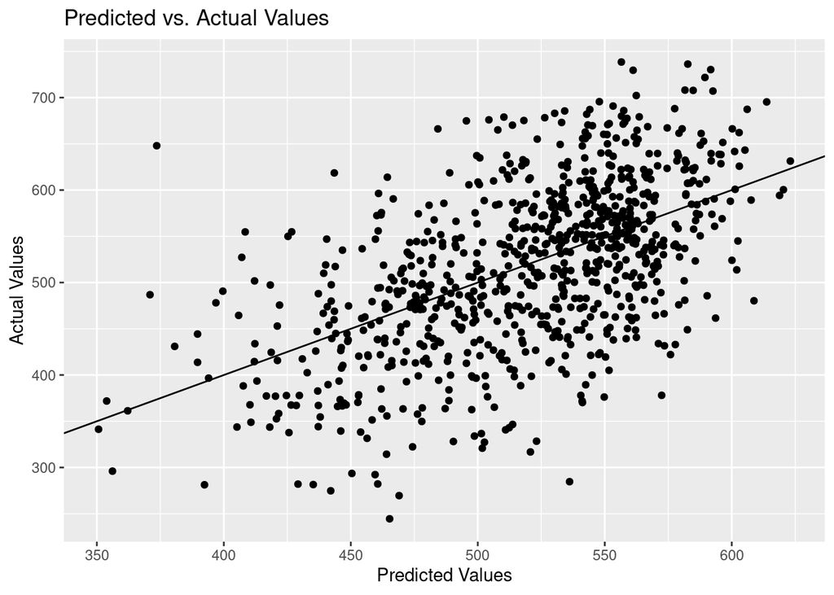

```r
plt_8 <- ggplot(data = test_set, aes(x = predicted, y = readingScore))
plt_8 + geom_point() +
  geom_abline(intercept=0, slope=1) +
  labs(x='Predicted Values', y='Actual Values', title='Predicted vs. Actual Values')
```

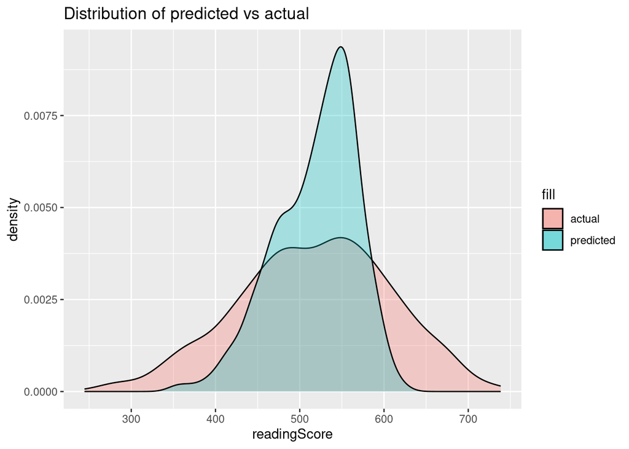

```r
plt_9 <- ggplot()
plt_9 + geom_density(data = test_set, aes(x = readingScore, fill = "actual"), alpha = 0.3) +
  geom_density(data = test_set, aes(x = predicted, fill = "predicted"), alpha = 0.3) +
  ggtitle("Distribution of predicted vs actual")
```

From the plot above, looks like we’re predicting mostly above the estimated value (mean of readingScore).

Let’s look at the performance metrics of regression model.

```r
# RMSE
cat("RMSE is ", sqrt(mean((test_set$readingScore - test_set$predicted)^2)))
```

```
## RMSE is  74.38593
```

```r
cat("MSE is ", mean((test_set$readingScore - test_set$predicted)^2))
```

```
## MSE is  5533.266
```

```r
summary(transform_final)
```

```
##
## Call:
## lm(formula = readingScore ~ grade + male + raceeth + expectBachelors +
##     motherBachelors + fatherHS + fatherBachelors + englishAtHome +
##     computerForSchoolwork + read30MinsADay + studentsInEnglish +
##     publicSchool + schoolSize + minutesPerWeekEnglish_sec_ordr +
##     studentsInEnglish_sec_ordr + grade_sec_ordr + mins_stu +
##     minutesPerWeekEnglish_log + studentsInEnglish_log, data = train_set)
##
## Residuals:
##      Min       1Q   Median       3Q      Max
## -249.821  -47.785    0.555   50.381  241.170
##
## Coefficients:
##                                                     Estimate     Std. Error
## (Intercept)                                   -1577.81473702   346.39272918
## grade                                           337.45810676    67.72484227
## maleY                                           -14.26284638     3.01569588
## raceethAsian                                     60.80991186    18.19027544
## raceethBlack                                     -3.55179064    17.26824654
## raceethHispanic                                  32.08486899    16.99634416
## raceethMore than one race                        44.04910783    18.47005533
## raceethNative Hawaiian/Other Pacific Islander    50.15291157    23.16517689
## raceethWhite                                     62.25509802    16.72513809
## expectBachelorsY                                 51.32630171     4.10587406
## motherBachelorsY                                 11.66646589     3.71121529
## fatherHSY                                         8.28434962     4.94879783
## fatherBachelorsY                                 15.84567243     3.87927699
## englishAtHomeY                                    8.44089063     5.47739022
## computerForSchoolworkY                           20.71817378     5.35420604
## read30MinsADayY                                  31.43945825     3.25710666
## studentsInEnglish                                -4.06379078     1.83932637
## publicSchoolY                                   -14.59102126     5.69294793
## schoolSize                                        0.00703408     0.00195355
## minutesPerWeekEnglish_sec_ordr                   -0.00007086     0.00002005
## studentsInEnglish_sec_ordr                        0.02812730     0.01564823
## grade_sec_ordr                                  -15.30621613     3.32563154
## mins_stu                                          0.00166749     0.00113411
## minutesPerWeekEnglish_log                         8.48440137     3.17544539
## studentsInEnglish_log                            47.20755175    22.47422646
```

[output cut: 17 more lines]

```
## studentsInEnglish                              -2.209             0.027237 *
## publicSchoolY                                  -2.563             0.010435 *
## schoolSize                                      3.601             0.000323 ***
## minutesPerWeekEnglish_sec_ordr                 -3.534             0.000416 ***
## studentsInEnglish_sec_ordr                      1.797             0.072379 .
## grade_sec_ordr                                 -4.602          0.000004381 ***
## mins_stu                                        1.470             0.141603
## minutesPerWeekEnglish_log                       2.672             0.007591 **
## studentsInEnglish_log                           2.101             0.035782 *
## ---
## Signif. codes:  0 '***' 0.001 '**' 0.01 '*' 0.05 '.' 0.1 ' ' 1
##
## Residual standard error: 73.47 on 2530 degrees of freedom
## Multiple R-squared:  0.3234, Adjusted R-squared:  0.317
## F-statistic: 50.39 on 24 and 2530 DF,  p-value: < 0.00000000000000022
```

#### j. Write a summary as if for a layman.

The data is sufficient to perform regression analysis. However, there are very few features which are correlated with the outcome (readingScore). Also, data representation is not presented in well fashion. The distribution and results are affected by outliers (extreme values).